# Lab 4

Sarah Bleakney

March 30, 2015

1. Two-sample T-test> ACT scores Consider the hypothesis that college-bound males and females have the same average ACT scores.

```r
act <- read.table('ACT_scores.txt', header=TRUE)
```

1. Write out the hypothesis that is tested by a two-sample t-test in this case.

Null Hypothesis: There is no difference between mean ACT scores of college-bound males and females

2. Using boxplots and summary statistics, report on the suitability of these data for a two-sample t-test to evaluate the hypothesis that the means are not different

```r
library(ggplot2)
library(dplyr)
library(tidyr)
library(magrittr)
new_act %>% group_by(sex) %>% summarize(m=mean(score), s=sd(score), n=n())
```

```
## Source: local data frame [2 x 4]
##
##       sex        m        s  n
## 1   Males 20.85714 7.998626 14
## 2 Females 20.42857 6.198192 14
```

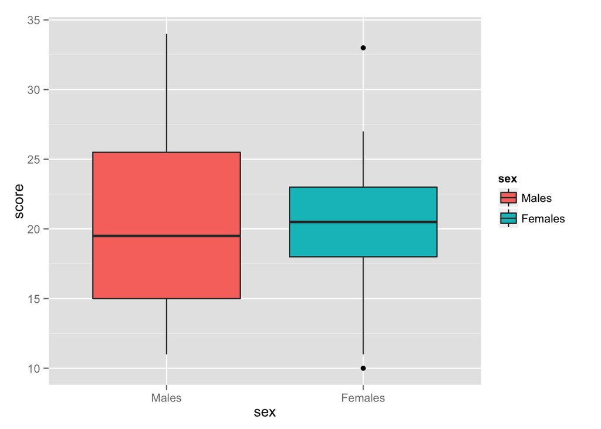

```r
ggplot(new_act, aes(x=sex,y=score,fill=sex)) + geom_boxplot()
```

```r
new_act %>% group_by(sex) %>% summarize(m=mean(score), sd=sd(score), n=n() )
```

```
## Source: local data frame [2 x 4]
##
##       sex        m       sd  n
## 1   Males 20.85714 7.998626 14
## 2 Females 20.42857 6.198192 14
```

3. Conduct a t-test to evaluate the hypothesis that mean ACTs are different

```r
t.test(act$Males,act$Females)
```

```
##
##  Welch Two Sample t-test
##
## data:  act$Males and act$Females
## t = 0.1585, df = 24.475, p-value = 0.8754
## alternative hypothesis: true difference in means is not equal to 0
## 95 percent confidence interval:
##  -5.147383  6.004526
## sample estimates:
## mean of x mean of y
##  20.85714  20.42857
```

With a p-value of 0.8754, I cannot reject the hypothesis that the means are not different

2. Two-sample t-tests. Cloud Seeding.

These data were collected in Southern Florida between 1968 and 1972 to test a hypothesis that seeding silver iodide into clouds can promote rainfall. They appear in a number of intriductory texts, including a favorite intermediate text of mine: Ramsay and Schafer’s The Statistical Sleuth. The data contain 52 weather events that were deemed suitable for seeding. On each day an airplane flew the clouds and a payload was released. It was randomly determined whether the payload would contain silver iodide or not, but the pilots were unaware of this, i.e. the pilots were blind to the treatment. Following the flight, radar was used to measure the precipitation falling from the cloud (in units of acre-feet).

```r
library(Sleuth3)
data(case0301)
head(case0301)
```

```
##   Rainfall Treatment
## 1   1202.6  Unseeded
## 2    830.1  Unseeded
## 3    372.4  Unseeded
## 4    345.5  Unseeded
## 5    321.2  Unseeded
## 6    244.3  Unseeded
```

```r
# Here are two ways to calculate a boxplot
# boxplot(Rainfall~Treatment, data=case0301)
# library(ggplot2)
# ggplot(data=case0301) + geom_boxplot(aes(x=Treatment, y=Rainfall))

# Here are two ways to calculate some summary statistics
#tapply(X=case0301$Rainfall, INDEX=case0301$Treatment, FUN=mean) # Calculate mean, repeat for sd
#library(dplyr)
#case0301 %>% group_by(Treatment) %>% summarize(m=mean(Rainfall), sd=sd(Rainfall), n=n() )
```

1. Using boxplots and summary statistics, report on the suitability of these data for a two-sample t-test to evaluate the hypothesis that seeding influences rainfall.

```r
case0301 %>% group_by(Treatment) %>% summarize(m=mean(Rainfall), sd=sd(Rainfall), n=n() )
```

```
## Source: local data frame [2 x 4]
##
##   Treatment        m       sd  n
## 1    Seeded 441.9846 650.7872 26
## 2  Unseeded 164.5885 278.4264 26
```

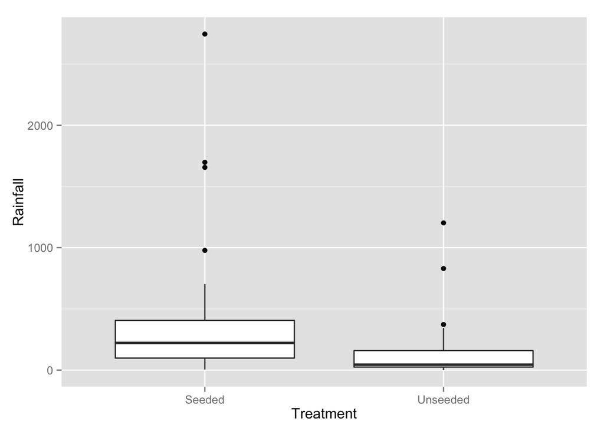

```r
ggplot(data=case0301) + geom_boxplot(aes(x=Treatment, y=Rainfall))
```

2. Conduct a t-test to evaluate the hypothesis that seeding influences rainfall and report the result.

```r
t.test(case0301$Rainfall~case0301$Treatment)
```

```
##
##  Welch Two Sample t-test
##
## data:  case0301$Rainfall by case0301$Treatment
## t = 1.9982, df = 33.855, p-value = 0.05377
## alternative hypothesis: true difference in means is not equal to 0
## 95 percent confidence interval:
##   -4.764295 559.556603
## sample estimates:
##   mean in group Seeded mean in group Unseeded
##               441.9846               164.5885
```

The p-value of .053 is slightly bigger than .05 and therefore I wouldn’t be comfortable rejecting the hypothesis that the true difference in means is 0 between seeded and unseeded rainfall. However it is very close.

3. Repeat a. and b. using a log-transform of the rainfall measurement. Which analysis do you prefer and why?

```r
new_case0301$log <- log(new_case0301$Rainfall)
new_case0301 %>% group_by(Treatment) %>% summarize(m=mean(log), sd=sd(log), n=n() )
```

```
## Source: local data frame [2 x 4]
##
##   Treatment        m       sd  n
## 1    Seeded 5.134187 1.599514 26
## 2  Unseeded 3.990406 1.641847 26
```

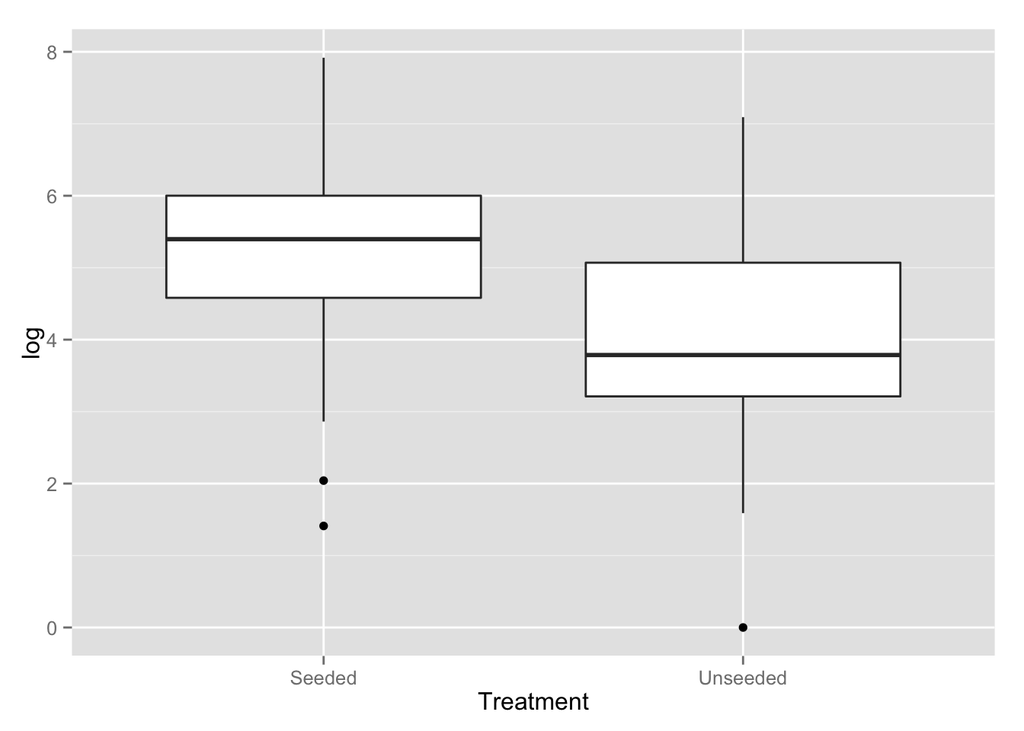

```r
ggplot(data=new_case0301) + geom_boxplot(aes(x=Treatment, y=log))
```

```r
t.test(new_case0301$log~case0301$Treatment)
```

```
##
##  Welch Two Sample t-test
##
## data:  new_case0301$log by case0301$Treatment
## t = 2.5444, df = 49.966, p-value = 0.01408
## alternative hypothesis: true difference in means is not equal to 0
## 95 percent confidence interval:
##  0.2408498 2.0467125
## sample estimates:
##   mean in group Seeded mean in group Unseeded
##               5.134187               3.990406
```

The mean of seeded is 5.13, and the mean of unseeded is 3.99. The standard deviations are much smaller than before the transformation; seeded has 1.5995 and unseeded has 1.6418, which makes sense with the log transformations. The boxplots are easier to understand without such a large scale and so many extreme outliers. The IQR of the boxplots still overlap so it’s not a clear difference, but the mean of Seeded lies outside of the IQR of Unseeded, and vice versa. The p-value calculated with the log values comes out to .014, which is much more significant than the p-value of .053 calculated with the regular rainfall rates. With this I would reject the null hypothesis. I prefer the second analysis using the log of rainfall. It takes care of the extreme outliers and smooths out the data set a bit, which makes it easier to interpret using the boxplot and also leads to significant results.

4. Why is it important that the pilots were unaware of whether they were seeding or not?

The pilots could potentially skew the results. Making this a blind experiment for them means they cannot subconsciously do something different whenever they are seeding versus not seeding. It’s a way to control for other potential bias.

5. Unfortunately, we do not have the date of the weather event. Why would it be helpful to have this information?

With the date, we could see what month these results were gathered. We could look at how rainfall rates varied per month in this location and control for that seasonal variation. The time of day could also be helpful. There could be a bias if most of the seeded clouds happened on summer afternoons where it is likely to rain already for example.

2. ANOVA

Here are some simple data describing average daily temperatures for different cities grouped by season.

```r
# Create a dataset
temp = c(60,65,62,64,63,80,85,82,84,83,90,95,101,99,100)
season = rep( c('Fall', 'Spring', 'Summer'), times=c(5,5,5))

data <- data.frame(temp=temp, season=season)
```

For the air temperature data, conduct an ANOVA and use the F-statistic to test the hypothesis that air temperature varies by season.

```r
aov.ex1 = aov(temp~season,data=data)
summary(aov.ex1)
```

```
##             Df Sum Sq Mean Sq F value   Pr(>F)
## season       2 2952.1  1476.1   158.7 2.34e-09 ***
## Residuals   12  111.6     9.3
## ---
## Signif. codes:  0 '***' 0.001 '**' 0.01 '*' 0.05 '.' 0.1 ' ' 1
```

```r
print(model.tables(aov.ex1,"means"),digits=3)
```

```
## Tables of means
## Grand mean
##
## 80.86667
##
##  season
## season
##   Fall Spring Summer
##   62.8   82.8   97.0
```

With an F-value of 158.7, I can conclude that there is a highly significant difference in temperature between seasons in this dataset. Our tiny p-value (2.34e-09) supports this claim.

3. Spock Conspiracy Trial.

This is another classic dataset. Dr. Benjamin Spock was a pediatrician who wrote a very popular book in 1948. In 1968, Dr Spock was accused of conspiring to violate the Selective Services Act by helping young men to medically avoid the military draft during the Vietnam War. His defence challeneged the case on the grounds that the jury did not contain a single woman, and therefore could not be random.

These data used here contain jury compositions for Spock’s judge and 6 other judges in the same court. For each jury, we have the fraction of the jury that was female.

```r
data(case0502)
```

1. Qualitatively describe these data using boxplots and summary statistics.

```r
case0502 %>% group_by(Judge) %>% summarize(m=mean(Percent), sd=sd(Percent), n=n() )
```

```
## Source: local data frame [7 x 4]
##
##     Judge        m        sd n
## 1       A 34.12000 11.941817 5
## 2       B 33.61667  6.582224 6
## 3       C 29.10000  4.592929 9
## 4       D 27.00000  3.818377 2
## 5       E 26.96667  9.010142 6
## 6       F 26.80000  5.968878 9
## 7 Spock's 14.62222  5.038794 9
```

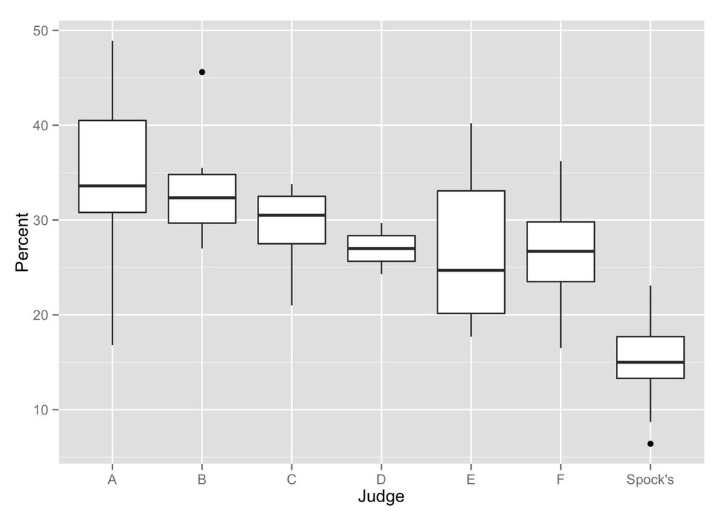

```r
ggplot(data=case0502) + geom_boxplot(aes(x=Judge, y=Percent))
```

As we can see from the summary statistics, all of the Judge’s mean percentage of women on the jury (except for Spocks’s) are in the 20’s or 30’s, with Judge F having the lowest mean of 26.8 and Judge A having the highest mean of 34.12. Spock’s mean lies much lower than all of these at 14.62. The standard deviations are also quite high, varing from 3.8 for Judge D to 11.94 for Judge A. The boxplot shows Spock’s values as much lower visually than the rest of the judges. The IQR of Spock’s data does not overlap with the IQR of any other judge. This makes me think there will be a significant difference between the fraction of the jury that was female in Spock’s trial versus all other judges.

2. Using an ANOVA, test the hypothesis that all of the judges have the same jury compositions on average and report your results.

```r
aov.ex2 = aov(Percent~Judge,data=case0502)
summary(aov.ex2)
```

```
##             Df Sum Sq Mean Sq F value  Pr(>F)
## Judge        6   1927   321.2   6.718 6.1e-05 ***
## Residuals   39   1864    47.8
## ---
## Signif. codes:  0 '***' 0.001 '**' 0.01 '*' 0.05 '.' 0.1 ' ' 1
```

With a F-value of 6.718, I would reject the hypothesis that all judges have the same jury composition on average.

3. Grouping together Judges A-F, perform a two-sample t-test to test the hypothesis that Spock’s judge consistently chooses juries with lower than expected women.

```r
case0502$Judge2 <- case0502$Judge == "Spock's"
t.test(case0502$Percent~case0502$Judge2)
```

```
##
##  Welch Two Sample t-test
##
## data:  case0502$Percent by case0502$Judge2
## t = 7.1597, df = 17.608, p-value = 1.303e-06
## alternative hypothesis: true difference in means is not equal to 0
## 95 percent confidence interval:
##  10.49935 19.23999
## sample estimates:
## mean in group FALSE  mean in group TRUE
##            29.49189            14.62222
```

With a p-value of 1.303e-06, I can conclude that Spock’s judge did consistently choose juries with lower than expected women.

4. Use another ANOVA to evaluate whether or not it was suitable to group together the other 6 judges.

```r
aov.ex4 = aov(V2~V1,data=Judges5)
summary(aov.ex4)
```

```
##             Df Sum Sq Mean Sq F value Pr(>F)
## V1           5  326.5   65.29   1.218  0.324
## Residuals   31 1661.3   53.59
```

This ANOVA tests tells me that there is not significant variance between the other judges (as seen through an F-value of 1.218) and that it was in fact suitable to group the 6 judges together.

5. How should your interpretation of the results in part (c) change if you rejected the hypothesis the other six judges were not all statistically the same?

If that were the case, then when I rejected the claim that all judges had the same composition of juries on average, my results could be pointing to another judge that had significantly different jury composition and not Spock’s jury. The only way our previous results make sense is if the other six judges were the same.